# Evaluation and Optimization

Reducing Capacity

## Learning Goals & Functions

### Learning Goals

In this script we’ll test the performance of models having different capacities.

### Functions in this session:

#### Reduce Capacity

Use basic `keras` functions that we’ve seen already:

| Function | Use |
| --- | --- |
| `layer_dense(units = xx)` | Change the number of nodes by adjusting the `units` argument in `layer_dense()` |
| `layer_dense()` | Reduce the number of hidden layers |

## Data Preparation

We already examined the data in the previous script. Here, we’ll just prepare the data as before.

```r
source("Boston_Z.R")
```

```r
# Prepare the validation set
index <- 1:101

val_data <- train_data[index,]
train_data <- train_data[-index,]

val_targets <- train_targets[index]
train_targets <- train_targets[-index]
```

## Variant 1: Larger or smaller layers

Here, we’ll try the whole range from $2^2 = 4$ to $2^{6} = 64$ neurons in each of our hidden layers.

To do this, we’ll define a function, `define_model` that allows us to define and compile our model. It takes one argument:

- `powerto = 4` - integer, the number of neurons as defined by two to the power of this value.

```r
# Generalise the model definitions
# Defaults to parameters we used in original case study.
define_model <- function(powerto = 4) {

  # cat("Defining model with ", 2^powerto, " neurons per hidden layer \n")

  # Define the model, using powerto arg for neuron number.
  network <- keras_model_sequential() %>%
    layer_dense(units = 2^powerto, activation = "relu", input_shape = 13) %>%
    layer_dense(units = 2^powerto, activation = "relu") %>%
    layer_dense(units = 1)

  # Compile as before
network %>% compile(
  optimizer = "rmsprop",
  loss = "mse",
  metrics = "mae"
)
}
```

In addition to that, I’ll define another function for training the model, `run_model`. It takes one argument:

- `epochs = 20` - integer, the numer of training epochs.

I won’t actually change the number of epochs here. it’s provided for your convenience. I’ve set `verbose = FALSE` to avoid lots of print out.

```r
run_model <- function(network, epochs = 20) {

  # cat("Training model ... \n")

  # Train the model and return the history (or just the network)
    network %>% fit(
      train_data,
      train_targets,
      epochs = epochs,
      batch_size = 512,
      validation_data = list(val_data, val_targets),
      verbose = FALSE
    )
}
```

The data is built into the function definitions, so calling my functions as below will provide the results we’ve seen previously.

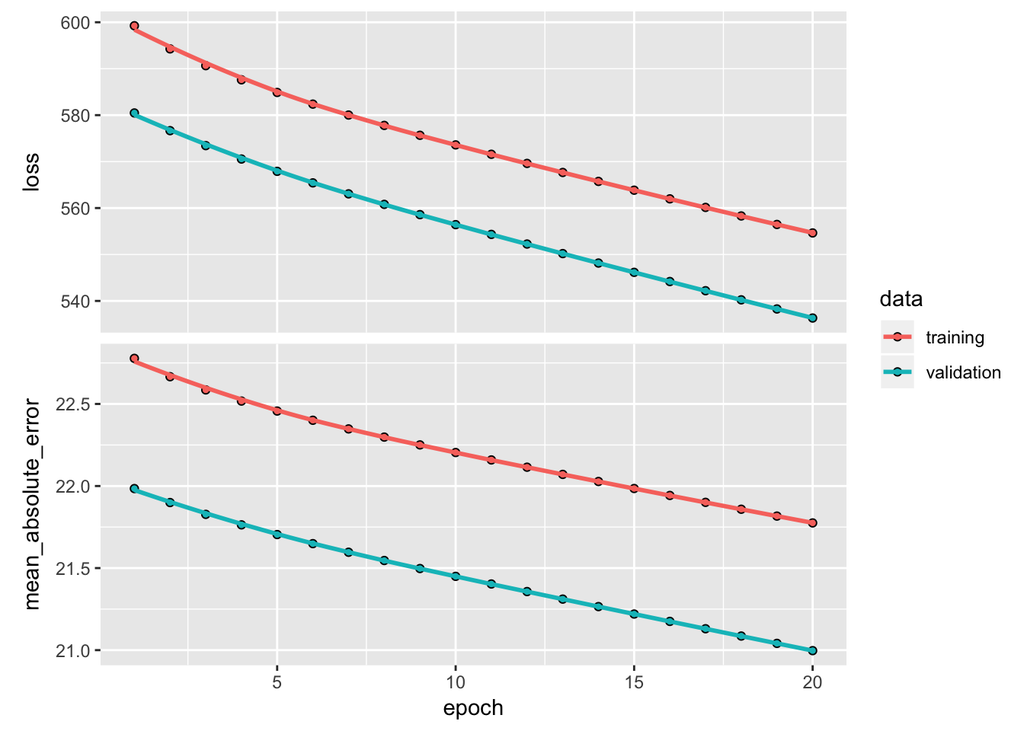

```r
define_model() %>%
  run_model() -> history_original

# Plot history using default:
history_original %>%
  plot()
```

```r
# Prep data frame for use later on:
history_original %>%
  data.frame() %>%
  mutate(nlayers = "2",
         powerto = "16") -> history_original
```

I’m using `purrr::map()` to calculate all the models reiteratively. Since I want to plot all the values together, I convert the history to a data frame. At the end we’ll have one large data frame with a `powerto` column that tells use how many neurons that model used.

```r
# Define number of neurons
powerto_input <- c(2:3,5:6)

powerto_input %>%
  map(define_model) %>%
  map(run_model) %>%
  map_df(data.frame, .id = "powerto") %>%
  mutate(powerto = as.character(factor(powerto, labels = 2^powerto_input)),
         nlayers = "2") -> history_powerto
```

From this, we can look at how the validation set accuracy and loss are affected. The line marked with red dots are the values we used in the original definition, above.

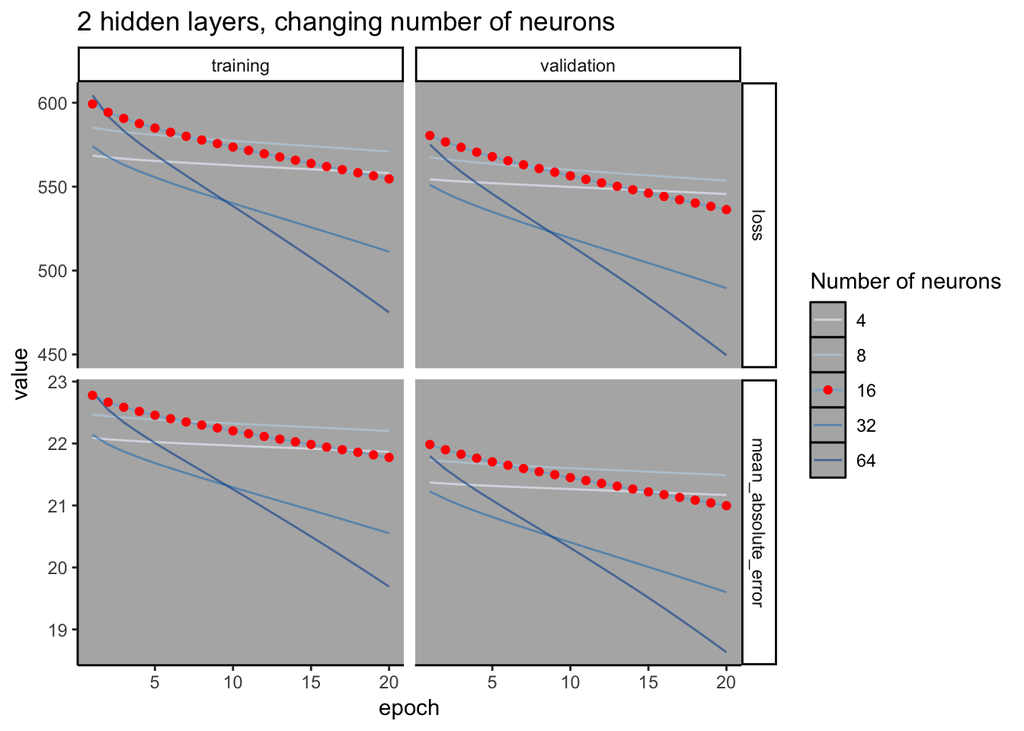

We can also count the number of parameters in each model:

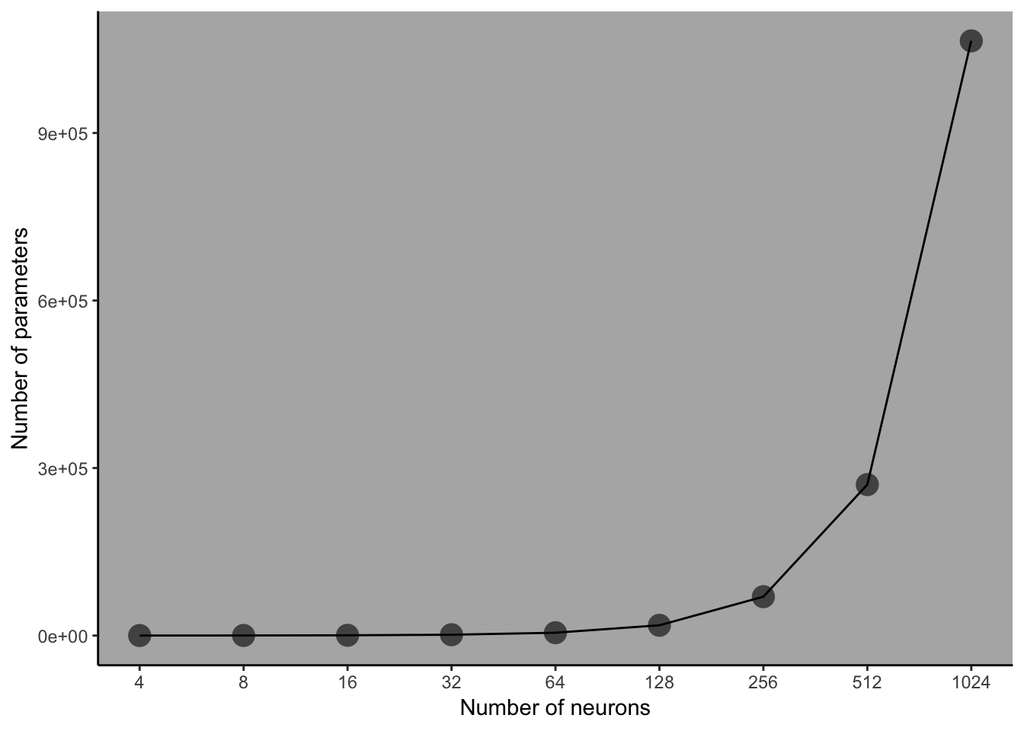

## Variant 2: Changing the number of layers layers

- `nlayers = 2` integer, the number of hidden layers. Minimum is 1.

To make my syntax with `purrr::map()` easier, I’m going to put it in the first position.

```r
define_model <- function(nlayers = 2, powerto = 4) {

  # cat("Defining model with ", 2^powerto, " neurons per ", nlayers," hidden layer(s) \n")

  # Establish model with single hidden, input, layer
   network <- keras_model_sequential() %>%
    layer_dense(units = 2^powerto, activation = "relu", input_shape = 13)

  # Add nlayers-1 number of additional layers
  if (nlayers > 1) {
  map(2:nlayers, ~ network %>%
        layer_dense(units = 2^powerto, activation = "relu")
  )
  }

  # Add final layer
  network %>%
    layer_dense(units = 1)

network %>% compile(
  optimizer = "rmsprop",
  loss = "mse",
  metrics = "mae"
)

}
```

Once again, I’ll use `purrr::map()` to calculate all the models reiteratively. This time I’ll have one large data frame and the `nlayers` column will correspond to how many layers that model contained.

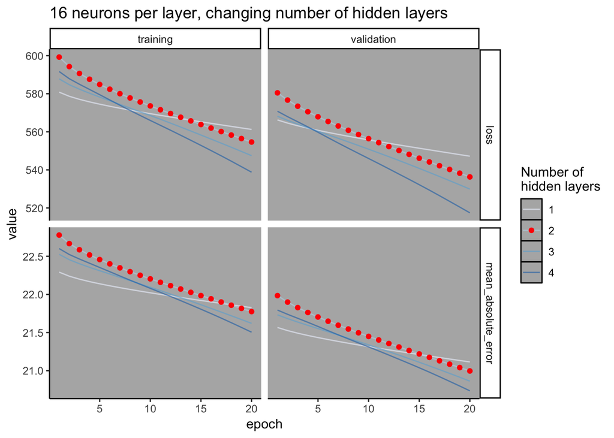

```r
# Define number of neurons
nlayers_input <- c(1,3:4)

nlayers_input %>%
  map(define_model) %>%
  map(run_model) %>%
  map_df(data.frame, .id = "nlayers") %>%
  mutate(nlayers = as.character(factor(nlayers, labels = nlayers_input)),
         powerto = "16") -> history_nlayers
```

Let’s take a look at the number of parameters here:

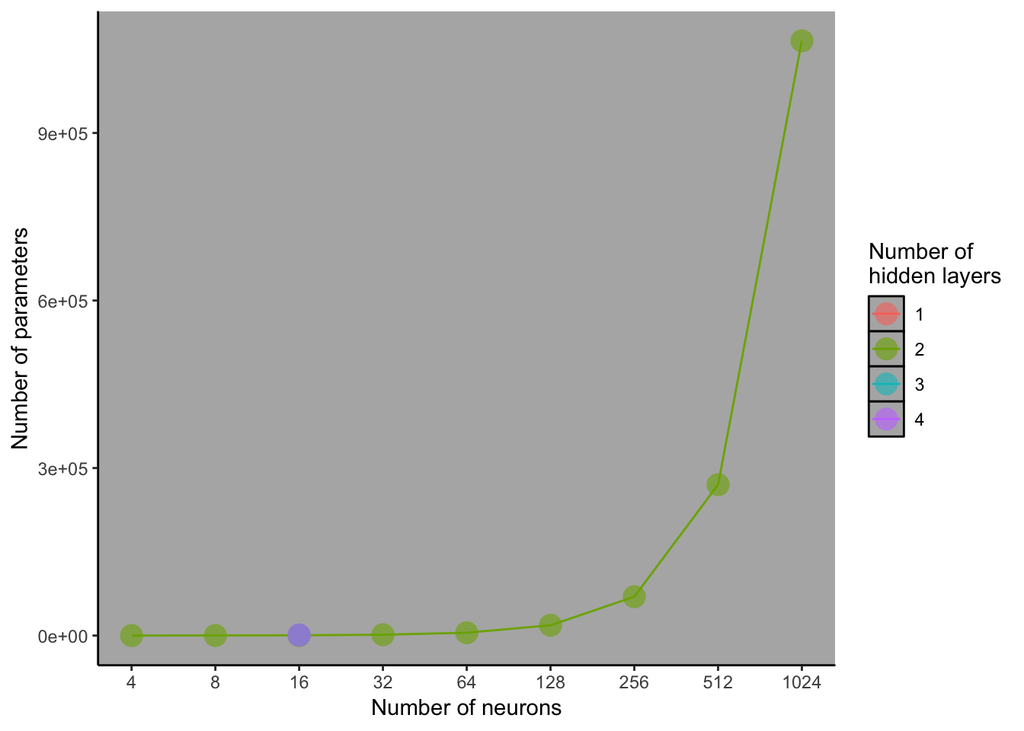